# Plot Circos genome plots with the `pycircos` package

## Description

This small notebook shows examples of how to use the python package `pycircos` to plot circular maps of the genome, enriched with different data layers.

- 'Circos' plots are a type of visualization that represent full genomes as a circle
- the circle is subdivided in sectors which can represent different chromosomes or contigs, if there are any
- the underlying data is primarily genome sequence information from a `.fasta` file, and genome annotation from a `.gff`
- Fasta and GFF files need to have the same chromosome identifiers (`seq_id`), as they are matched

## Requirements

- need to install the `python-circos` package from bioconda, or using pip
- needs `biopython` for sequence import and transformations

To install a fresh conda environment and use this as the kernel:

```
conda create -p myenv -c conda-forge -c bioconda biopython matplotlib
conda activate myenv
pip install python-circos requests
```

To install from a python chunk in a jupyter notebook:

```
import sys
!{sys.executable} -m pip install python-circos biopython requests matplotlib
```

## Input data

- first step is to make input data available in `.fasta` and `.gff` format
- this repo has example files in the `data/` dir

## Run the python function

This will plot the example map:

```
python source/circos_plot.py \
  data/spyogenes_genome.fna \
  data/spyogenes_genome.gff \
  output/circos.png
```

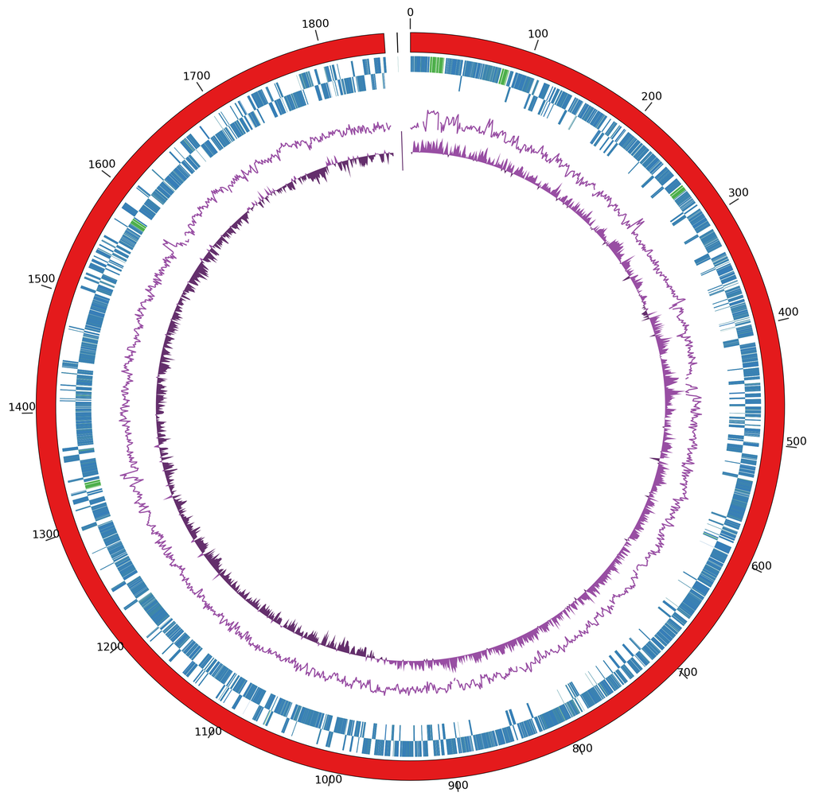

```python
from IPython.display import Image
Image(filename='../output/circos.png')
```

## Session info

```python
!pip freeze
```

[output not shown]